# ** Healthcare Analysis **

**Library loaded successfully**

```python
import pandas as pd
import numpy as np
import matplotlib.pyplot as plt
import seaborn as sns

sns.set_style("whitegrid")
```

**Files loaded successfully**

```python
# First, check if the files exist in your current directory
import os
import pandas as pd

# Print current working directory to see where we are
print(f"Current working directory: {os.getcwd()}")

# List files in the current directory to see what's available
print("Files in current directory:")
print(os.listdir())

# Try to load from the current directory instead of /mnt/data/
# Adjust these paths based on where your files are actually located
try:
    dental = pd.read_csv("Dental_Health.csv")
    mental = pd.read_csv("Mental_Health.csv")
    primary = pd.read_csv("Primary_Health.csv")
    mua = pd.read_csv("Mua_Health.csv")
    print("Files loaded successfully!")
except FileNotFoundError as e:
    print(f"Error: {e}")
    print("Please check the correct path to your CSV files")
```

```
Current working directory: C:\Users\KARAN SANJAY DUKARE
Files in current directory:
['.anaconda', '.bash_history', '.conda', '.condarc', '.continuum', '.gitconfig', '.idlerc', '.ipynb_checkpoints', '.ipython', '.jupyter', '.matplotlib', '.ms-ad', '.virtual_documents', '.vscode', 'anaconda_projects', 'AppData', 'Application Data', 'average_loan_size_by_type.png', 'Car.csv', 'Contact…
Files loaded successfully!
```

**Q1 Dataset Structure Analysis**

1. What are the number of rows and columns in each healthcare dataset?
2. Which dataset is the largest?

```python
datasets = {
    "Dental": dental,
    "Mental": mental,
    "Primary": primary,
    "MUA": mua
}

for name, df in datasets.items():
    print(f"\n{name} Dataset")
    print("Rows:", df.shape[0])
    print("Columns:", df.shape[1])
```

```
Dental Dataset
Rows: 500
Columns: 74

Mental Dataset
Rows: 500
Columns: 72

Primary Dataset
Rows: 500
Columns: 74

MUA Dataset
Rows: 500
Columns: 74
```

**Q2 Missing & Invalid Data Detection**

1. Identify columns with missing values or placeholders.
2. Which dataset has the highest percentage of missing data?

```python
for name, df in datasets.items():
    print(f"\n{name} Missing Values (%)")
    print((df.isnull().mean() * 100).round(2))
```

```
Dental Missing Values (%)
Source_ID                           0.0
Source_Name                         0.0
Status_Code                         0.0
Status_Description                  0.0
Type_Code                           0.0
                                  ...
Provider_Type                     100.0
Rural_Status_Code                   0.0
Rural_Status_Desc                   0.0
HPSA_Designation_Pop_Type_Desc      0.0
BHCMIS_OrgID                      100.0
Length: 74, dtype: float64

Mental Missing Values (%)
Source_ID                          0.0
Source_Name                        0.0
Status_Code                        0.0
Status_Description                 0.0
Type_Code                          0.0
                                  ...
HPSA_Withdrawn_Date                0.0
HPSA_Withdrawn_Date_String         0.0
Provider_Type                     59.2
Rural_Status_Desc                  0.0
HPSA_Designation_Pop_Type_Desc     0.0
Length: 72, dtype: float64

Primary Missing Values (%)
Source_ID                           0.0
Source_Name                         0.0
Status_Code                         0.0
Status_Description                  0.0
Type_Code                           0.0
                                  ...
Provider_Type                     100.0
Rural_Status_Code                   0.0
Rural_Status_Desc                   0.0
HPSA_Designation_Pop_Type_Desc      0.0
BHCMIS_OrgID                      100.0
Length: 74, dtype: float64

MUA Missing Values (%)
MUA_SOURCE_ID              0.0
MUA_AREA_CD                0.0
MCD_FIPS_Cd              100.0
MCD_CENSUS_CD            100.0
MCD_NM                   100.0
                         ...
MUA_WITHDRAWAL_DT        100.0
MUA_WITHDRAWAL_DT_TXT    100.0
RURAL_STATUS_CD            0.0
RURAL_STATUS_DESC          0.0
PROVIDER_1000_POP         97.2
Length: 74, dtype: float64
```

**Q3 Duplicate Records Check**

1. Are there duplicate healthcare records across datasets?
2. How many duplicates exist per dataset?

```python
for name, df in datasets.items():
    print(f"{name} Duplicate Records:", df.duplicated().sum())
```

```
Dental Duplicate Records: 0
Mental Duplicate Records: 0
Primary Duplicate Records: 0
MUA Duplicate Records: 0
```

# Shortage & Population Analysis

**Q4 Degree of Shortage Comparison**

1. Compare the Degree_of_Shortage across Dental, Mental, and Primary healthcare.
2. Which healthcare category has the most severe shortages?

```python
print("Dental:", dental['Degree_of_Shortage'].value_counts())
print("\nMental:", mental['Degree_of_Shortage'].value_counts())
print("\nPrimary:", primary['Degree_of_Shortage'].value_counts())
```

```
Dental: Series([], Name: count, dtype: int64)

Mental: Degree_of_Shortage
Not applicable    500
Name: count, dtype: int64

Primary: Series([], Name: count, dtype: int64)
```

**Q5 Population Coverage Analysis**

1. Compare Designation_Pop, Estimated_Served_Pop, and Estimated_Underserved_Pop.
2. Which healthcare type impacts the largest underserved population?

```python
print("Dental Underserved Population:", dental['Estimated_Underserved_Pop'].sum())
print("Mental Underserved Population:", mental['Estimated_Underserved_Pop'].sum())
print("Primary Underserved Population:", primary['Estimated_Underserved_Pop'].sum())
```

```
Dental Underserved Population: 0.0
Mental Underserved Population: -3910574.0
Primary Underserved Population: 0.0
```

**Q6 State-wise Healthcare Shortages**

1. Which top 10 states have the highest number of healthcare shortage designations?

```python
combined_states = pd.concat([
    dental['State_Abbr'],
    mental['State_Abbr'],
    primary['State_Abbr']
])

top_states = combined_states.value_counts().head(10)
top_states
```

```
State_Abbr
CA    138
OK    126
AZ    104
NM     93
WA     88
HI     85
RI     74
MN     65
SD     58
MT     54
Name: count, dtype: int64
```

**Q7 Urban vs Rural Analysis**

1. Compare shortages in Rural vs Non-Rural areas using RURAL_STATUS_DESC.
2. Which areas face more shortages?

```python
rural_counts = pd.concat([
    dental['Rural_Status_Desc'],
    mental['Rural_Status_Desc'],
    primary['Rural_Status_Desc']
]).value_counts()

rural_counts
```

```
Rural_Status_Desc
Rural        968
Non-Rural    532
Name: count, dtype: int64
```

**Q8 Designation Status Analysis**

1. How many records are Active vs Withdrawn across healthcare categories?

```python
for name, df in datasets.items():
    if 'Status_Description' in df.columns:
        print(f"\n{name} Status")
        print(df['Status_Description'].value_counts())
```

```
Dental Status
Status_Description
Designated    495
Withdrawn       5
Name: count, dtype: int64

Mental Status
Status_Description
Withdrawn    500
Name: count, dtype: int64

Primary Status
Status_Description
Designated    500
Name: count, dtype: int64
```

**Q9 Trend Over Time**

1. Analyze the trend of healthcare designations over the years using Designation_Date.
2. Has the number of shortages increased or decreased?

```python
dental['Designation_Date'] = pd.to_datetime(dental['Designation_Date'], errors='coerce')
yearly_trend = dental['Designation_Date'].dt.year.value_counts().sort_index()

yearly_trend
```

```
Designation_Date
2002    165
2003      5
2005      5
2006      4
2007      8
2009      5
2010      9
2011     21
2012     15
2013      9
2014      5
2015     11
2016      3
2017      2
2018      3
2019    230
Name: count, dtype: int64
```

# Provider Availability Analysis

```python
for name, df in datasets.items():
    if 'Designation Status' in df.columns:
        print(f"\n{name} Status Count")
        print(df['Designation Status'].value_counts())
```

# Visualization Section (Matplotlib / Seaborn)

**Q11 HPSA Score Distribution (Histogram)**

[figure not shown]

```python
plt.figure()
sns.histplot(dental['Degree_of_Shortage'])
plt.title("Dental Degree of Shortage Distribution")
plt.show()
```

**Q12 State-wise Shortage (Bar Chart)**

1. Plot a bar chart showing the top 10 states with the highest number of healthcare shortages.

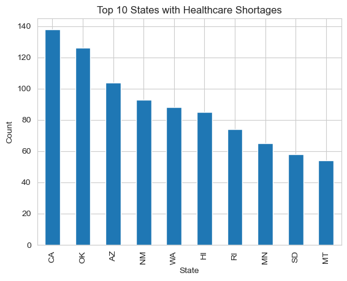

```python
plt.figure()
top_states.plot(kind='bar')
plt.title("Top 10 States with Healthcare Shortages")
plt.xlabel("State")
plt.ylabel("Count")
plt.show()
```

**Q13 Population Affected (Boxplot)**

1. Create boxplots comparing population affected across Dental, Mental, and Primary Care HPSA datasets.

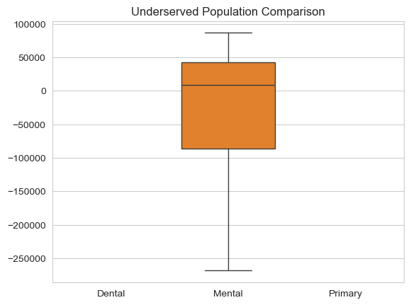

```python
pop_df = pd.DataFrame({
    'Dental': dental['Estimated_Underserved_Pop'],
    'Mental': mental['Estimated_Underserved_Pop'],
    'Primary': primary['Estimated_Underserved_Pop']
})

plt.figure()
sns.boxplot(data=pop_df)
plt.title("Underserved Population Comparison")
plt.show()
```

{HPSA Score} {Population} {Provider Shortage (if available)}

[figure not shown]

```python
combined_rural = pd.concat([
    dental[['Rural_Status_Desc']],
    mental[['Rural_Status_Desc']],
    primary[['Rural_Status_Desc']]
])

plt.figure()
# Fix: Use the correct column name 'Rural_Status_Desc' instead of 'RURAL_STATUS_DESC'
sns.countplot(x='Rural_Status_Desc', data=combined_rural)
plt.title("Healthcare Shortages: Urban vs Rural")
plt.show()
```

[figure not shown]

```python
corr_data = dental[[
    'Degree_of_Shortage',
    'Designation_Pop',
    'Estimated_Underserved_Pop'
]].corr()

plt.figure()
sns.heatmap(corr_data, annot=True)
plt.title("Correlation Heatmap – Dental Health")
plt.show()
```